# Worked Problem Assignment 4

### Kyle Taft

```python
# Import packages
import matplotlib.pyplot as plt
import numpy as np
```

### Background

The problem that I chose to work on is the potential inside of a rectangular pipe where it has three grounded sides and a side at x = +b that has a potential of $V_0(y)$. This problem was inspiried by the "Introduction to Electrodynamics" by David J. Griffiths problem set. Specifically problen 3.15. The original problem is as follows:

*A rectangular pipe, running parallel to the z-axis (from −∞ to +∞), has three grounded metal sides, at y = 0, y = a, and x = 0. The fourth side, at x = b, is maintained at a specified potential V0(y).*

### Solution

We must first start with Laplace's equation:

$$\nabla^2V(x,y,z) = 0$$

Applying separation of variables we get:

$$V(x,y,z) = X(x)Y(y)Z(z)$$

Plugging this into Laplace's equation we get:

$$\frac{1}{X}\frac{d^2X}{dx^2} + \frac{1}{Y}\frac{d^2Y}{dy^2} + \frac{1}{Z}\frac{d^2Z}{dz^2} = 0$$

As we discussed in class this equation implies that each term must be equal to a constant that all add up to zero. This gives us the following three equations:

$$X(x) = Ae^{kx} + Be^{-kx}$$$$Y(y) = Ce^{ky} + De^{-ky}$$$$Z(z) = Ee^{kz} + Fe^{-kz}$$

This is our general solution but we can simplify it further. Specifically in this problem we do not have any dependence on the z variable. This means that we can set k3 = 0 and remove the Z(z) term from our solution. Additionally we would expect the x direction to decay exponentially from its $V_0(y)$ and for the y direction to only have a sinusodial dependence. This leaves us with the following solution:

$$V(x,y) = X(x)Y(y)$$$$X(x) = Ae^{kx} + Be^{-kx}$$$$Y(y) = Csin(ky) + Dcos(ky)$$

We can now apply boundary conditions to our solution:

1. Knowing V(y = 0) = 0 we can say: $Y(y = 0) = Csin(ky) + Dcos(ky) = 0$

   -> This implies that D = 0
2. Knowing V(y = a) = 0 we can say: $Y(y = a) = Csin(ka) = 0$

   -> This implies that $k = \frac{n\pi}{a}$ where n is an integer
3. Knowing V(x = 0) = 0 we can say: $X(x = 0) = Ae^{kx} + Be^{-kx} = 0$

   -> This implies that A = -B

This leaves us with the following solutions:

$$X(x) = Ae^{\frac{n \pi}{a}x} - Ae^{-\frac{n \pi}{a}x}$$$$Y(y) = Csin(\frac{n\pi}{a}y)$$

Putting this back into our general solution we get:

$$V(x,y) = Csin(\frac{n\pi}{a}y)(Ae^{\frac{n \pi}{a}x} - Ae^{-\frac{n \pi}{a}x})$$$$V(x,y) = ACsin(\frac{n\pi}{a}y)(e^{\frac{n \pi}{a}x} - e^{-\frac{n \pi}{a}x})$$

This infact gives us an infinite number of solutions. We set $C_n = AC$ to get the following:

$$V(x,y) = \sum_{n=1}^\infty C_nsin(\frac{n\pi}{a}y)(e^{\frac{n \pi}{a}x} - e^{-\frac{n \pi}{a}x})$$

Now to solve for AC we need to use Fourier's trick along with the boundary condition $V(x=b) = V_0(y)$. We know that:

$$\int_{0}^{a}sin(\frac{n\pi}{a}y)sin(\frac{m\pi}{a}y)dy = \frac{a}{2}\delta_{nm}$$

And with plugging in our boundary condition we get:

$$V_0(y) = \sum_{n=1}^\infty C_nsin(\frac{n\pi}{a}y)(e^{\frac{n \pi}{a}b} - e^{-\frac{n \pi}{a}b})$$

We can now multiply both sides by $sin(\frac{m\pi}{a}y)$ and integrate from 0 to a:

$$\int_{0}^{a}V_0(y)sin(\frac{m\pi}{a}y)dy = \sum_{n=1}^\infty C_n(e^{\frac{n \pi}{a}b} - e^{-\frac{n \pi}{a}b})\int_{0}^{a}sin(\frac{n\pi}{a}y)sin(\frac{m\pi}{a}y)dy$$

Which gives us:

$$C_m = \frac{2}{a(e^{\frac{m \pi}{a}b} - e^{-\frac{m \pi}{a}b})}\int_{0}^{a}V_0(y)sin(\frac{m\pi}{a}y)dy$$

We can now plug this back into our general solution to get:

$$V(x,y) = \sum_{n=1}^\infty sin(\frac{n\pi}{a}y)(e^{\frac{n \pi}{a}x} - e^{-\frac{n \pi}{a}x}) \frac{2}{a(e^{\frac{n \pi}{a}b} - e^{-\frac{n \pi}{a}b})}\int_{0}^{a}V_0(y)sin(\frac{n\pi}{a}y)dy$$

### Analysis

Now that we have a solution we can analyze it. First we can look at the case where $V_0(y) = 1$. This gives us the following solution:

$$V(x,y) = \sum_{n=1}^\infty sin(\frac{n\pi}{a}y)(e^{\frac{n \pi}{a}x} - e^{-\frac{n \pi}{a}x}) \frac{2}{a(e^{\frac{n \pi}{a}b} - e^{-\frac{n \pi}{a}b})}\int_{0}^{a}sin(\frac{n\pi}{a}y)dy$$$$V(x,y) = \sum_{n=1}^\infty sin(\frac{n\pi}{a}y)(e^{\frac{n \pi}{a}x} - e^{-\frac{n \pi}{a}x}) \frac{2}{a(e^{\frac{n \pi}{a}b} - e^{-\frac{n \pi}{a}b})} (\frac{-a}{n \pi} (cos(n\pi)-1))$$$$V(x,y) = \sum_{n=1,3,5,..}^\infty sin(\frac{n\pi}{a}y)(e^{\frac{n \pi}{a}x} - e^{-\frac{n \pi}{a}x}) \frac{4}{n\pi(e^{\frac{n \pi}{a}b} - e^{-\frac{n \pi}{a}b})}$$

Also, when we look at x = b we get:

$$V(x=b,y) = \sum_{n=1,3,5,..}^\infty sin(\frac{n\pi}{a}y)(e^{\frac{n \pi}{a}b} - e^{-\frac{n \pi}{a}b}) \frac{4}{n\pi(e^{\frac{n \pi}{a}b} - e^{-\frac{n \pi}{a}b})}$$$$V(x=b,y) = \sum_{n=1,3,5,..}^\infty sin(\frac{n\pi}{a}y) \frac{4}{n\pi}$$

This is the solution that we would expect. It is a constant potential of 1 along the edge from y = 0 to y = a. We can now plot this solution to see what it looks like.

### Code

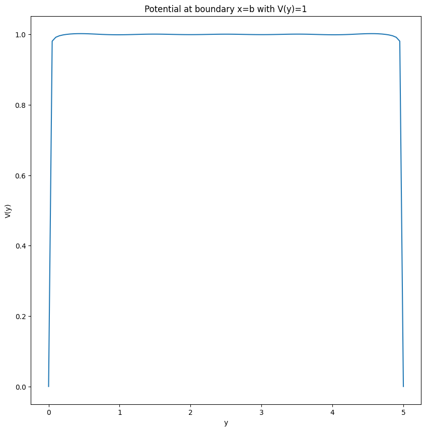

```python
# Visualize simple case at boundary

def V(y, a, terms = 1000):
    potential = 0
    for n in range(1, terms, 2):
        potential += (4/(n*np.pi)) * np.sin((n*np.pi*y)/a)
    return potential

plt.figure(figsize=(10,10))
a = 5
y = np.linspace(0,a,100)

plt.plot(y, V(y,5))
plt.xlabel('y')
plt.ylabel('V(y)')
plt.title('Potential at boundary x=b with V(y)=1')
```

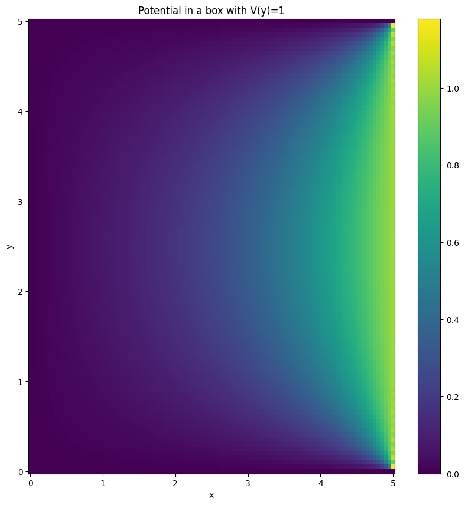

```python
# Plotting our full potential with V(y) = 1

def Vfull(x, y, a, b, terms = 50):
    potential = 0
    for n in range(1, terms, 2):
        potential += (4/(n*np.pi)) * np.sin((n*np.pi*y)/a) * (np.exp(n*np.pi*x/a) - np.exp(-n*np.pi*x/a))/(np.exp(n*np.pi*b/a) - np.exp(-n*np.pi*b/a))
    return potential

# Plot heatmap of potential
x = np.linspace(0,5,100)
y = np.linspace(0,5,100)
X, Y = np.meshgrid(x,y)
Z = Vfull(X,Y,5,5, 100)
plt.figure(figsize=(10,10))
plt.pcolormesh(X,Y,Z)
plt.colorbar()
plt.xlabel('x')
plt.ylabel('y')
plt.title('Potential in a box with V(y)=1')
plt.show()
```